# Amazon Polly: Can it handle accented English?

## Multilingualism in the United States

The United States has become increasingly multilingual since its inception as a nation, and even more so in recent years. The United States Census Bureau estimated that around 20.8% of the United States population (approximately 60 million people) reported speaking a language other than English at home (Tamasi, Susan and Lamont Antieau. *Language and Linguistc Diversity in the US: An Introduction*. Routledge: New York (2015): 192.). As of 2021, that proportion has risen to 21.6% and [constitutes](https://data.census.gov/cedsci/table?t=Language%20Spoken%20at%20Home&tid=ACSST1Y2021.S1601) over 67 million people. Spanish, Chinese, Tagalog, Vietnamese, French, Korean and German each have over a million speakers in the United States, and there are hundreds of other languages that lay claim to linguistic communities.

[figure not shown]

*Source: Migration Policy (2019 American Cummunity Survey)*

Despite the undeniable presence of lingusitic diversity, the United States has remained embarrassingly monolingual. Around 80% of the population speaks only English, and Hawaii (English and Hawaiian) is the only [officially](https://www.mustgo.com/worldlanguages/us-languages/) bilingual state (Louisiana, Maine and New York are de facto bilingual due to their large numbers of non-English speakers). There is a heavy burden is on English Second Language (ESL) and non-English speakers to learn a new language to get through everyday life in the United States. In fact, the United States has a troubling history of trying to [exterminate](https://blogs.illinois.edu/view/25/653544) all non-English speech, and the issues that have stemmed from its monolingual attitude have even bled over into the technology and artificial intelligence (AI) sectors.

## Problems With AI and Accented Speech

Oftentimes, engineers create speech recognition software with white, English-speaking and Americanized voices in mind, a bias which researchers have only just begun to investigate. A study from March 2020 [compared](https://www.pnas.org/doi/10.1073/pnas.1915768117) the performances of automated speech recognition (ASR) systems developed by Amazon, Apple, Google, IBM and Microsoft, varying the race of the speaker. Concerningly, all the ASR systems did a significantly poorer job transcribing the speech of Black English speakers than they did for white English speakers – the error rates were nearly twice as large for every ASR system.

[figure not shown]

*Note: WER is the error score, for which lower values indicate higher accuracy.*

If racial bias exists even when all the subjects are native English speakers living in the United States, then one can only imagine how ill-equipped ASR software is when it comes to faithfully interpreting foreign-accented English. Given that all the major technology companies tested in the study have headquarters in the United States and boast a large number of both American and foreign employees, improving the accuracy of their ASR systems should be a major priority, especially considering how widespread such software is.

[figure not shown]

*Source: AI Multiple*

Our personal interest in examining the difficulties of transcribing accented English accurately stems from Claire's experience as a [sports editor](https://emorywheel.com/author/claire-fenton/) at the Emory Wheel. She and her staff writers often have to conduct interviews for articles, both to obtain background research and to get quotes from the article subjects which can be incorporated into the story. Unless the interviewee states otherwise, the Wheel's policy is to record all interviews. The most popular recording tool used among the Wheel's staff is the web-based audio recorder [Otter.ai] (https://otter.ai/), which has the advantage of transcribing the audio during the recording process. Otter.ai also partners with Zoom to transcribe the audio for Zoom calls when participants desire.

While Otter.ai is an extremely helpful tool for journalists who want to avoid listening to hours of interview recordings searching for a couple sentences, it is far from perfect. Claire has often noticed that Otter struggles to punctuate the sentences correctly, often creating long run-ons. It also sometimes fails to transcribe the audio accurately, even when the interviewee speaks SAE. In fact, Claire and her staff writers interview people who speak with both non-standard American English and foreign-accented English, and the transcription accuracy is noticably worse for these interviewees.

During the editing process, Claire has noticed that her writers sometimes directly copy and paste Otter.ai's transcription into the article without editing for grammatical or transcription mistakes, resulting in some inaccurate and sloppy quotes almost making it to print. Journalists have a responsibility to represent the views and speech of their interviewees faithfully, and erroneous transcriptions can clearly inhibit that process. As such, examining the accuracy of Amazon's speech-to-text and text-to-speech services is of particular interest to us, given that it directly impacts Claire's work and potentially that of news outlets worldwide.

## Introduction to Amazon Polly

[Amazon Polly](https://aws.amazon.com/blogs/aws/polly-text-to-speech-in-47-voices-and-24-languages/) is a machine learning text-to-speech software that falls under the Amazon Web Services (AWS) umbrella. Users provide Amazon Polly with text and choose the text language and the desired voice, and Amazon Polly converts the text into audio. Amazon Polly offers a total of 47 voices, both male and female, across 24 languages – not all voices are available for all every custumization option Amazon Polly has.

One of the most interesting features of Amazon Polly is its ability to read English in a foreign accent. Using the `<lang xml:lang="en-US"></lang>`, we can make Amazon Polly read the English text with the accent of the chosen language. For example, using the setup pictured below, Amazon Polly will say "Hi my name is Claire and I can say anything that you type" in a French accent.

[figure not shown]

```python
from IPython.display import Audio, display

sound_file = '/content/speech_20221106020108797.mp3'
Audio(sound_file, autoplay=True)
```

[output not shown]

While the full catalogue of Amazon Polly voices is not available for this type of manipulation, a fairly wide range is. Languages and voices from every continent except Antarctica are available, but for some languages the option to test a male voice disappears. Amazon Polly also gives users the option to create fully bilingual voices and even construct their own accents by creating a phonetic library. However, the accented English feature is as far as the scope of our project hopes to explore.

## Project Setup

After playing around with the various accented English through which Amazon Polly can speak, we felt confident that if we passed its foreign-accented English through Amazon Transcription, we would receive a high number of errors. Thus, our goal is as follows: to use Amazon Polly to create audio files of different English accents applied to the same sentence, to feed those audio files into Amazon Transcription, to quantify the error for each accent and to compare the results.

[figure not shown]

The above map pins the countries from which the languages we chose originate. We wanted to have a mix of European, Asian and standard English accents to choose from. The Joanna voice is our baseline, and we chose all female voices both to control for gender and due to the limitations of Amazon Polly.

To create our data set of sentences, we used an online [random sentence generator](https://randomwordgenerator.com/sentence.php) to create a data set containing 100 nonsensical and amusing sentences which we will force Amazon Polly to read in the different accents. Each accent will read the same sentences; thus, we can control for potential differences in the input text for Amazon Polly.

```python
import pandas as pd
```

```python
sentences = pd.read_excel('100Random.xlsx')
sentences.head()
```

Because one of the main functionalities of speech-to-text services like Amazon Transcription is to save users the time it takes to write and edit manually, we will judge the accuracy of Amazon Transcription on the number of edits required to make its rendering match the original sentence.

## Hypotheses

Since we have very little experience with ASR systems and their potential racial biases, our hypotheses as to the results we obtain are not well-founded. However, we can look to others' research to guide our expectations. A 2022 study from DiChristofano et al. found that ASR services generally performed the worst for speakers whose first language was Mandarin Chinese (DiChristofano, Alex et al, "Performance Disparities Between Accents in Automatic Speech Recognition" (2022): 6.) They performed the second-worst for Korean, followed by Spanish, Russian, Portuguese, Arabic, French, German and Dutch.

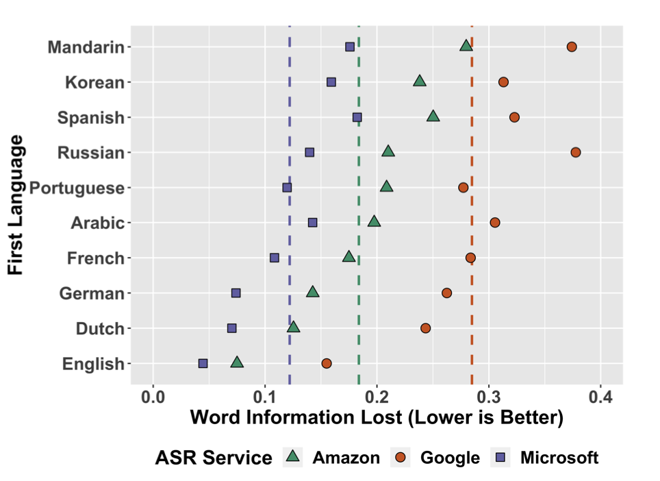

Although not all of our languages are represented in DiChrisofano's study, it appears as though ASR services have the most difficulty with Asian languages. Thus, we hypothesize that Amazon Transcription will have the most errors for **Aditi** (Hindi) and **Seoyeon** (Korean). Based off the above chart, Spanish will be the third-worst, French will be fourth and the British-accented English, since it is the closest to our American English control, will have the fewest errors.

## From Text to Amazon Polly

Our first task is to create six audio files for each sentence in our Excel file `100Random.xlsx`, one for each accent. First, let's take a look at our data by importing the `pandas` package so that we can read the Excel file into a Python data frame.

```python
import pandas as pd
```

```python
df = pd.read_excel('100Random.xlsx') #sentences file

print(df)
```

[output not shown]

Clearly, the data frame is a collection of nonsense sentences – it will be interesting to see how well Amazon Polly converts them into speech. Before we can begin we need to import several packages, including `boto3`, which allows for the creation and managment of AWS services.

```python
import boto3
from botocore.exceptions import BotoCoreError, ClientError
from contextlib import closing
import os
import sys
import subprocess
import io
```

We need to create a `polly` client using the region `us-east-1` and an array of Strings containing the names of the voices we want to examine.

```python
polly = boto3.client('polly', region_name='us-east-1')

voices = ["Joanna", "Emma", "Lea", "Seoyeon", "Lucia", "Aditi"]
```

```python
for voice in voices:
    i = 0
    for sentence in df["Original"]:
        i += 1
        response = polly.synthesize_speech(Text= sentence, OutputFormat="mp3",
        VoiceId=f"{voice}", LanguageCode = "en-US")

        if "AudioStream" in response:
            with closing(response["AudioStream"]) as stream:
                output = os.path.join(f"/home/ec2-user/SageMaker/{voice}", f"{voice + str(i)}.mp3")
                try:
                    with open(output, "wb") as file:
                        file.write(stream.read())
                except IOError as error:
                    print(error)
                    sys.exit(-1)
        else:
            print("Could not stream audio")
            sys.exit(-1)
```

We now have 600 audio files and need a place to store it all. We created an Amazon S3 bucket called `speechfilesqtmg3` and we want to move everything there. To accomplish this, we need to loop through every voice in `voices`, enter the corresponding folder, loop through every audio file within and move them to our new bucket. After creating a String containing the file path, we can use the `mv` command from the AWS CLI to transfer the variable `$string` representing the audio file to the S3 bucket.

```python
voices = ["Joanna", "Emma", "Lea", "Seoyeon", "Lucia", "Aditi"]
string = ""
for voice in voices:
    for name in os.listdir(f"/home/ec2-user/SageMaker/{voice}"):
        string = f"/home/ec2-user/SageMaker/{voice}/{name}"
        !aws s3 mv $string s3://speechfilesqtmg3 #change
```

## From Amazon Polly to Amazon Transcription

Our next task is to take all the audio files which Amazon Polly generated and convert them back to text using Amazon Transcription, a process which requires us to import a the `time`, `urllib` and `json` libraries.

```python
import time
import urllib
import json
```

Just as we did with Amazon Polly, we need to use `boto3` to create a transcribe client.

```python
transcribe_client = boto3.client('transcribe')
```

We need to create a function called `transcribe_file_up` that takes the name of the new file, the uri of the input file and the transcribe client as arguments and uploads the audio files to Amazon Transcribe. The input file type is specified as 'mp3' and the language is American English.

```python
def transcribe_file_up (job_name, file_uri, transcribe_client):
    transcribe_client.start_transcription_job(
        TranscriptionJobName=job_name,
        Media= {'MediaFileUri': file_uri},
        MediaFormat='mp3',
        LanguageCode="en-US"
    )
```

```python
def transcribe_file_down (job_name, file_uri, transcribe_client):
    max_tries = 0
    while max_tries < 60:
        max_tries+=1
        job = transcribe_client.get_transcription_job(TranscriptionJobName = job_name)
        job_status = job['TranscriptionJob']['TranscriptionJobStatus']
        if job_status == 'FAILED':
            print(f"{job_name} Failed")
        elif job_status == 'COMPLETED':
            response = urllib.request.urlopen(job['TranscriptionJob']['Transcript']['TranscriptFileUri'])
            data = json.loads(response.read())
            text = data['results']['transcripts'][0]['transcript']
            return(text)
        else:
            print(f"Waiting for {job_name}, trying again")
            time.sleep(10)
```

The final step is to create a data frame containing the original sentences, a language dictionary that holds the voice name as the key and their language as the value and an empty data frame to store our final data configuration.

```python
orig_df = pd.read_excel('100Random.xlsx')

lang_dict = {'Joanna' : 'English', 'Emma': 'British', 'Lea': 'French', 'Seoyeon': 'Korean', 'Aditi' : 'Hindi', 'Lucia' : 'Castilian Spanish'}

df = pd.DataFrame(columns = ['Name', 'Language', 'Original', 'Transcription'])
```

At last, we can create Amazon Transcription files for each accent. We loop through the array `names` containing the names of the voices and create 100 job names and file uris for each. Calling the `transcribe_file_up` function we defined previously allows us to upload all the mp3 files we obtained from Amazon Polly.

Through trial and error, we learned that Amazon Transcript can only handle 100 files at once; therefore, we need to download all the transcription files for one voice before moving on to the next. Once again, we create a job name and file uri for each audio file and use our `transcribe_file_down` method to obtain our Amazon Transcription text file. We then add the voice name, language, the original sentnece and the Amazon Transcription ouput to our data frame.

```python
names = ['Joanna','Emma','Lea','Seoyeon','Aditi','Lucia']
for name in names:
    for i in range(1,101):
        job_name = '5'+name+str(i)
        file_uri = f's3://speechfilesqtmg3/{name}{i}.mp3' #change
        transcribe_file_up(job_name, file_uri, transcribe_client)
    time.sleep(60)

    for i in range(1,101):
        job_name = '5'+name+str(i)
        file_uri = f's3://hw3-license-mayblum-1/{name}{i}.mp3' ##maybe change this??

        transcription = transcribe_file_down(job_name, file_uri, transcribe_client)
        original = orig_df['Original'].iat[i-1]
        language = lang_dict[name]

        df = df.append({'Name' : name , 'Language' : language, 'Original' : original, 'Transcription' : transcription },
            ignore_index = True)
```

We downloaded our completed data frame in csv format so that we would not have to run the code again to obtain results. Unfortunately, the **Seoyeon** voice (Korean) produced erroroneous, low-quality data; around half of the final files were blank, so we had to drop **Seoyeon** entirely from our final data set. Although we were disappointed not to have an East Asian voice represented, **Aditi** (Hindi) still provides us with Asian accent data.

```python
df = pd.read_csv('transcribedData.csv')
df = df[df.Name != 'Seoyeon']
```

Our final step was to quantify the error rates among the voices. We decided to use the **Levenshtein Distance**, a method used to calculate the difference between two strings, as our benchmark.

[figure not shown]

*Source: Wikipedia*

Thankfully, Python has a library called `textdistance` that contain a `levenshtein` function that will do all the calculations for us.

```python
from textdistance import levenshtein
```

We create a `Score` column in the data frame and apply the Levenshtein Distance formula to the `Original` and `Transcription` columns to find the difference between the original randomized sentence and eventual Amazon Transcription output for each of our data points.

```python
df['Score'] = df.apply(lambda x: levenshtein.distance(x['Original'],  x['Transcription']), axis=1)
df
```

[output not shown]

```python
df.to_csv('comparisonData.csv')
```